# SharedObjectPool

Alexey Serdyuk

22/10/2020

# JMH Performance Test for SharedObjectPool

This document analyzes results of JMH performance tests for different implementations of the interface `SharedObject` to estimate their overhead.

## Introduction to the library `shared-object-pool`

The library `shared-object-pool` implements a pool of objects which may be pre-created or created on demand, each object may be used by multiple clients. A typical example of a pooled object is a “ticking” price feed for a particular currency, connected over network to a remote live data source. Such objects have the following characteristics:

- An object could be relatively expensive to construct.
- An object could be relatively resource-hungry, that is it may consume CPU, memory or network resources as long as it is “alive”.
- The same object is often required in different parts of the application.

Due to the characteristics, it makes sense to keep such objects in a pool. When some part of an application requires a particular object, for example a price feed for a particular currency, it obtains the object from the pool. Different parts of the application access the same implementation object managed by the pool, reducing overall resource consumption.

Using an object pool for expensive objects opens way for various optimizations. If the implementation object is easy to construct but expensive to keep “alive”, the pool may be configured to immediately dispose of the implementation object as soon as no client is using it. On the other hand, if the implementation object is expensive to construct but relatively cheap to keep “alive”, the pool may be configured to keep unused objects for some time, so that the object will be immediately available when a client asks for it.

Actively managing objects in the pool instead of just caching them requires to keep track of whether clients are using any particular pooled object. We decided to use an explicit lifecycle management: the client explicitly requests the pool to provide a particular object, and the client explicitly informs the pool that it does not require the object anymore. The pool may implement additional “safety net” to catch cases when a client forgot to dispose of an object it does not require anymore, but that is just a “safety net”, not the normal approach.

Using an explicit lifecycle management is facilitated by using wrappers for pooled objects. Whenever a client requests an object from the pool, the pool provides a wrapper for the implementation object. Using wrappers instead of pooled implementation objects allows to improve control on how objects are used. In particular, when a client disposes of a wrapper, any subsequent method calls on the wrapper throws exceptions, allowing to immediately spot programming errors.

The interface `SharedObject` provides a wrapper for implementation objects managed by a pool. Whenever a client requires a pooled object, it requests the object from the pool, and the pool returns a wrapper. When the client does not require the object anymore, it disposes of the object. The pool keeps track whether there are active wrappers for each pooled implementation object, and may dispose a pooled implementation object once there are no active wrappers referencing it.

The purpose of this document is to compare performance of several implementations of the wrapper interface `SharedObject`.

## Description of tests

We have run JMH performance tests using an artificial implementation object which just consumes a requested number of CPU tokens using the JMH framework. A CPU token defines an abstract amount of time, but the required time grows linearly with a number of CPU tokens. A method call that consumes 10 CPU tokens runs 100 times faster as a method call that consumes 1000 CPU tokens, if no other application logic is involved. To test an overhead of wrapper objects for method calls of different complexity, we have run tests with method calls which consume 0, 10, 100, 200, 300, …, 1000 CPU tokens.

The following implementations of the interface `SharedObject` were tested:

- Baseline uses an implementation object directly, without any wrappers. Comparing each implementation of the `SharedObject` interface with the baseline allows to estimate the overhead of a particular wrapper.
- “sync” is a hand-crafted wrapper using standard Java synchronization.
- “reflection-sync” is a reflection-based implementation using standard Java synchronization. Using reflection may be slower as the hand-crafted version, but it allows to use the same implementation for all object types, whereas the hand-crafted implementation involves additional work for each object type, and introduces more risks due to a possible programmer’s error.
- “locking” is a hand-crafted implementation using `ReadWriteLock`. Compared to the “sync” implementation, the “locking” implementation allows a higher level of parallelism when a wrapper object is used by multiple threads.
- “reflection-locking” is a reflection-based implementation using `ReadWriteLock`. The comparison between “locking” vs. “reflection-locking” is the same as between “sync” and “reflection-sync”: the reflection-based implementation may be slower, but the hand-crafted requires more efforts to implement and maintain.

## Analysis of test results

This section analyzes the test results we consider the most important. Raw data is available for extended analysis.

### Overhead of wrappers

To estimate an overhead of wrappers vs. the implementation object, we compare test results in a single-thread mode. In this mode concurrency plays no role, so any observed slowdown is due to the wrapper implementation, not due to several threads fighting for resources.

The following chart shows duration (nanoseconds) each wrapper implementation takes to execute a method call which consumed the specified number of CPU time tokens.

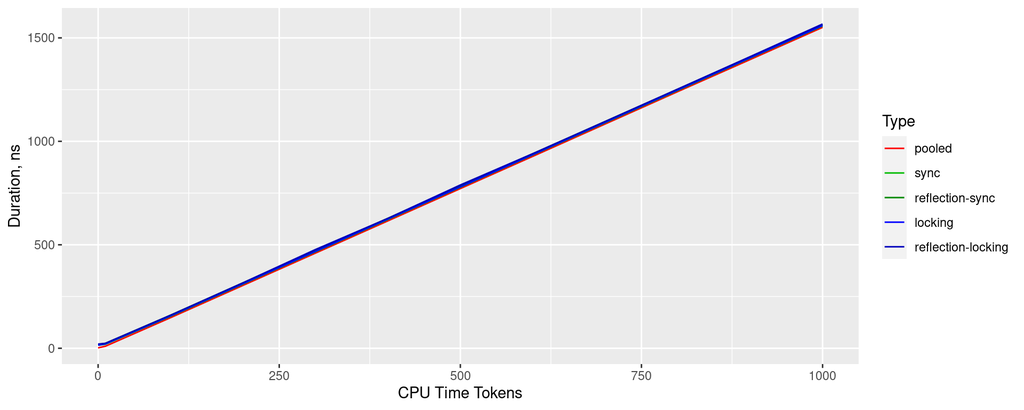

On the chart we immediately see:

- The duration of method calls scale linearly with the number of CPU time tokens (as promised by the JMH framework).
- The difference between implementation is very small, that is an overhead of all wrapper implementations is very low.

The following table provides duration in ns of method calls for all implementations, and compares them with the baseline “pooled” implementation (that is, without any wrapper). The column “Duration” shows duration of a method call in ns, the column “Diff” shows a difference in ns between a particular wrapper and the no-wrapper baseline.

| Tokens | pool Duration | sync Duration | sync Diff | reflection-sync Duration | reflection-sync Diff | locking Duration | locking Diff | reflection-locking Duration | reflection-locking Diff |
| --- | --- | --- | --- | --- | --- | --- | --- | --- | --- |
| 0 | 1.9 | 14.9 | 13.0 | 18.6 | 16.7 | 14.9 | 13.0 | 20.4 | 18.5 |
| 10 | 9.7 | 19.1 | 9.4 | 23.7 | 14.0 | 20.9 | 11.1 | 23.9 | 14.2 |
| 100 | 147.9 | 154.3 | 6.4 | 159.9 | 12.0 | 156.4 | 8.4 | 159.7 | 11.8 |
| 200 | 303.9 | 310.1 | 6.2 | 316.2 | 12.3 | 312.3 | 8.4 | 316.3 | 12.5 |
| 300 | 459.8 | 466.1 | 6.3 | 472.2 | 12.4 | 468.2 | 8.4 | 477.2 | 17.3 |
| 400 | 615.7 | 622.0 | 6.3 | 628.0 | 12.3 | 624.3 | 8.7 | 627.8 | 12.2 |
| 500 | 771.8 | 777.9 | 6.1 | 783.9 | 12.1 | 779.9 | 8.1 | 789.1 | 17.4 |
| 600 | 927.6 | 934.0 | 6.5 | 940.0 | 12.4 | 935.8 | 8.2 | 940.5 | 12.9 |
| 700 | 1084.0 | 1089.8 | 5.8 | 1096.1 | 12.1 | 1092.1 | 8.1 | 1096.2 | 12.2 |
| 800 | 1240.3 | 1245.8 | 5.5 | 1251.6 | 11.4 | 1248.2 | 8.0 | 1252.5 | 12.3 |
| 900 | 1395.3 | 1401.9 | 6.6 | 1407.2 | 12.0 | 1403.9 | 8.7 | 1409.3 | 14.0 |
| 1000 | 1551.0 | 1557.1 | 6.2 | 1563.0 | 12.1 | 1559.5 | 8.5 | 1567.1 | 16.1 |

The overhead of each particular wrapper is the same for most durations of the implementation method call (that is, the number of CPU time tokens), except the shortest calls. According to the table, the average overhead in ns is:

- “sync”: 7.0
- “reflection-sync”: 12.6
- “locking”: 9.0
- “reflection-locking”: 14.3

Synchronized implementations have a lower overhead as implementations based on `ReadWriteLock` (but synchronized implementations do not scale well with the number of threads, as we will see below). Reflection-based implementations are slower, as expected, but not much so: a difference of 5-6 ns is negligible for most the real-world scenarios where it makes sense to pool objects.

### Scalability of wrappers

In this section we compare wrappers when they are used by multiple threads. Note that this test is about the case when a particular wrapper is used by multiple threads, it assumes that the underlying implementation object is perfectly concurrent and does not add any multi-threaded penalty at all. In most real-life scenarios the underlying implementation would add additional multi-threaded penalty, and the wrapper overhead will constitute smaller part of the total overhead.

The following chart shows duration (nanoseconds) each wrapper implementation takes to execute a method call which consumed the specified number of CPU time tokens, when running with 4 threads (the number of CPU cores available when running the test).

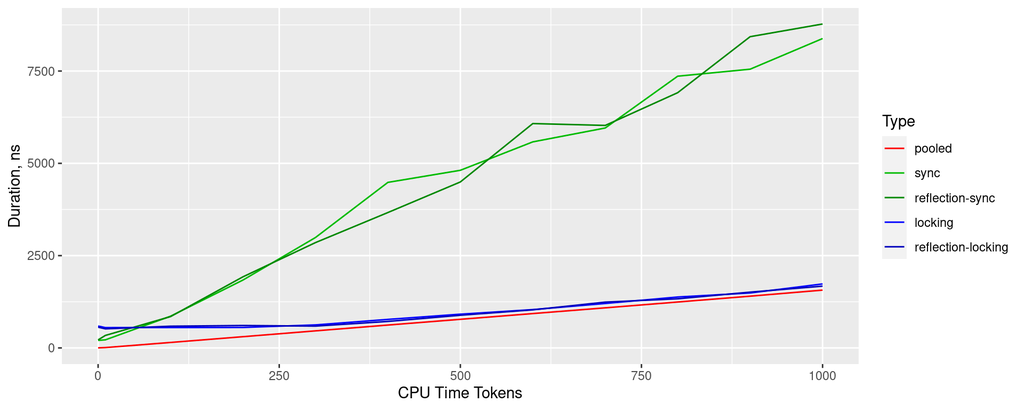

- For the baseline implementation (“pooled”, red line) there is no multi-threaded penalty: as long as the number of available CPU cores is enough to run all test threads, the threads do not compete for resources in this test scenario.
- Synchronization-based wrappers (green lines) scale pretty badly and show very high volatility, that is different test runs vary greatly. This is not a surprise: the synchronized wrapper can be used only by one thread at each give time, so when running with 4 concurrent threads, each method call in average waits for method calls from 3 other threads, that is each method call is in average 4 times slower as without the wrapper.
- Wrappers based on `ReadWriteLock` have a nearly-constant overhead of 550 ns when running a method which consumes less than 300 CPU tokens. For longer-running methods, these wrappers scale very similar to the baseline, adding just a near-constant overhead (100 - 150 ns).

| Tokens | pool Duration | sync Duration | sync Diff | reflection-sync Duration | reflection-sync Diff | locking Duration | locking Diff | reflection-locking Duration | reflection-locking Diff |
| --- | --- | --- | --- | --- | --- | --- | --- | --- | --- |
| 0 | 1.9 | 204.6 | 202.7 | 218.6 | 216.7 | 593.1 | 591.2 | 561.8 | 559.9 |
| 10 | 9.7 | 218.9 | 209.1 | 338.7 | 329.0 | 550.4 | 540.7 | 516.8 | 507.0 |
| 100 | 148.3 | 859.8 | 711.5 | 848.9 | 700.6 | 552.3 | 404.0 | 588.6 | 440.3 |
| 200 | 304.7 | 1839.3 | 1534.6 | 1927.3 | 1622.6 | 554.4 | 249.8 | 607.5 | 302.8 |
| 300 | 462.3 | 2990.7 | 2528.5 | 2853.1 | 2390.8 | 623.8 | 161.6 | 590.9 | 128.6 |
| 400 | 619.7 | 4484.6 | 3864.8 | 3667.7 | 3048.0 | 773.0 | 153.3 | 718.1 | 98.4 |
| 500 | 775.1 | 4811.8 | 4036.7 | 4495.9 | 3720.8 | 914.4 | 139.3 | 885.4 | 110.3 |
| 600 | 930.7 | 5581.4 | 4650.8 | 6077.3 | 5146.6 | 1038.4 | 107.8 | 1031.8 | 101.2 |
| 700 | 1086.0 | 5957.3 | 4871.3 | 6027.0 | 4941.0 | 1204.4 | 118.4 | 1240.9 | 154.9 |
| 800 | 1243.6 | 7360.7 | 6117.1 | 6914.0 | 5670.4 | 1379.6 | 136.0 | 1331.3 | 87.7 |
| 900 | 1402.0 | 7550.4 | 6148.4 | 8430.9 | 7028.9 | 1488.8 | 86.8 | 1511.5 | 109.5 |
| 1000 | 1566.3 | 8380.5 | 6814.2 | 8774.4 | 7208.1 | 1734.1 | 167.8 | 1674.1 | 107.8 |

## Conclusion

Based on the performed tests, we conclude:

- Hand-crafted wrappers are faster than reflection-based wrappers, but the difference is very small (about 5 nanoseconds per method call). Except of cases when methods of pooled objects are repeatedly called in a tight loop, the efforts to provide and maintain a hand-crafted implementation are not worth the effort.
- Implementation based on synchronization is slightly faster than implementation based on `ReadWriteLock`, when a wrapper is used by a single thread. On the other hand, when a wrapper could be used by multiple threads, the synchronization-based implementation does not scale at all, whereas the implementation based on `ReadWriteLock` scales perfectly. A gain in case of a single-threaded usage is just about 2 nanoseconds per method call. Even if the wrapper is intended to be used in a single-threaded context, in most cases it is not worth the risk of very large performance penalty if the wrapper is accessed from multiple threads.
- As a result, we recommend using the “reflection-locking” implementation (that is, the implementation based on reflection and `ReadWriteLock`), unless performance tests in a particular context shows that another implementation is required to fulfill the requirements.